# pfam

Load libraries

```r
library(readr)
library(dplyr)
library(tidyverse)
library(vegan)
library(randomForest)
library(reshape2)
library(rstatix)
library(vegan)
```

Load file containing pfam info and metadata.

```r
pfam <- read.delim("~/Documents/UMich/papers/GrowthDefenseTradeOff/pfam/function.txt")
bins_extendedinfo <- read.csv("~/Documents/UMich/papers/GrowthDefenseTradeOff/R output/bins_extendedinfo.csv")
```

Filter out pfam, read gene calls, and combine contig info with pfam info.

```r
filtered_pfam <- pfam %>%
  dplyr::filter(source == "Pfam")

gene.calls.txt <- read.delim("~/Documents/UMich/papers/GrowthDefenseTradeOff/other output/gene-calls-txt")

tmp <- gene.calls.txt %>%
  dplyr::select(gene_callers_id, contig)

pfam_summary <- inner_join(filtered_pfam, tmp, by = "gene_callers_id")
```

Add bin column and filter only manually curated MAGs.

```r
# extract bin info
pfam_summary <- pfam_summary %>% mutate(bin = str_extract(contig, "^[^-]+"))

pfam_MAGs <- pfam_summary %>%
  dplyr::filter(str_detect(bin, "_MAG_"))
```

Load df with list of MAGs whose mean rel abundance shifted significantly between treatments.

```r
sig_bins <- read.delim("~/Documents/UMich/papers/GrowthDefenseTradeOff/R output/sig_bins.tsv")


# merge the pfam df with bin category information
sig_bins <- sig_bins %>% # rename bin column
  rename_at("bin_name", ~'bin')

merged_pfam <- inner_join(pfam_MAGs, sig_bins, by = "bin")
```

Next, calculate relative proportion of pfams.

```r
# calculate total Pfams per bin
total_pfams_per_bin <- merged_pfam %>%
  group_by(bin) %>%
  summarise(total_pfams = n())

# calculate count of each Pfam per bin
pfam_counts_per_bin <- merged_pfam %>%
  group_by(bin, accession) %>%
  summarise(count = n(), .groups = 'drop')

# calculate proportions
pfam_proportions <- merge(pfam_counts_per_bin, total_pfams_per_bin, by = "bin") %>%
  mutate(proportion = count / total_pfams)

# add group info to the proportions data
pfam_proportions_with_group <- merge(pfam_proportions, merged_pfam %>% dplyr::select(bin, group) %>% distinct(), by = "bin")

# save
write.csv(pfam_proportions_with_group, "../R output/pfam_proportions_with_group.csv")
```

Split into resistant and suceptible categories

```r
# split data by group for comparison
increase_data <- subset(pfam_proportions_with_group, group == "resistant")
decrease_data <- subset(pfam_proportions_with_group, group == "susceptible")

# identify Pfam categories exclusive to each group and those present in both
pfam_group_presence <- pfam_proportions_with_group %>%
  group_by(accession) %>%
  summarize(groups_present = list(unique(group))) %>%
  ungroup()

pfam_group_presence$exclusive_to_increase <- sapply(pfam_group_presence$groups_present, function(x) "resistant" %in% x & !("susceptible" %in% x))
pfam_group_presence$exclusive_to_decrease <- sapply(pfam_group_presence$groups_present, function(x) "susceptible" %in% x & !("resistant" %in% x))
pfam_group_presence$in_both_groups <- sapply(pfam_group_presence$groups_present, function(x) "resistant" %in% x & "susceptible" %in% x)

# extract lists of Pfam categories
exclusive_to_increase <- pfam_group_presence$accession[pfam_group_presence$exclusive_to_increase]
exclusive_to_decrease <- pfam_group_presence$accession[pfam_group_presence$exclusive_to_decrease]
pfams_in_both_groups <- pfam_group_presence$accession[pfam_group_presence$in_both_groups]

# save resistant only pfam
write.csv(pfam_proportions_with_group, "../R output/pfams_resistantonly.csv")
# save pfams_in_both_groups
write.csv(pfams_in_both_groups, "../R output/pfams_in_both_groups.csv")
```

Perform Wilcoxon tests on relative proportions for Pfams in both groups

```r
# filter the data to include only those Pfam categories found in both groups
filtered_proportions_for_tests <- pfam_proportions_with_group %>%
  filter(accession %in% pfams_in_both_groups)

# test for each Pfam category
test_results <- filtered_proportions_for_tests %>%
  group_by(accession) %>%
  wilcox_test(proportion ~ group) %>%
  ungroup() %>%
  adjust_pvalue(method = "BH") %>%
  add_significance() %>%
  filter(p.adj < 0.05)
```

```r
# Merge test_results with functional descriptions
significant_pfams_with_desc <- merge(test_results, merged_pfam %>% select(accession, function.) %>% distinct(), by = "accession")

# Let's join this with the original proportions data to get the mean proportions for "increase" and "decrease" groups
significant_proportions <- merge(pfam_proportions_with_group, significant_pfams_with_desc, by = "accession")

# calculate mean proportions for these significant Pfams in each group
mean_proportions_significant <- significant_proportions %>%
  group_by(accession, function., group) %>%
  summarise(mean_proportion = mean(proportion), .groups = 'drop')

# rename using caps for plot
mean_proportions_significant$group[mean_proportions_significant$group == "resistant"] <- "Resistant"
mean_proportions_significant$group[mean_proportions_significant$group == "susceptible"] <- "Susceptible"

# save df with mean proportions of enriched Pfams
write.csv(mean_proportions_significant, "../R output/enriched_pfams.csv")
```

```r
# replace labels for the all shared pfams (4226 unique pfams) and save
filtered_proportions_for_tests$group[filtered_proportions_for_tests$group == "resistant"] <- "Resistant"
filtered_proportions_for_tests$group[filtered_proportions_for_tests$group == "susceptible"] <- "Susceptible"
write.csv(filtered_proportions_for_tests, "../R output/filtered_proportions_for_tests.csv")
```

Figure 2A

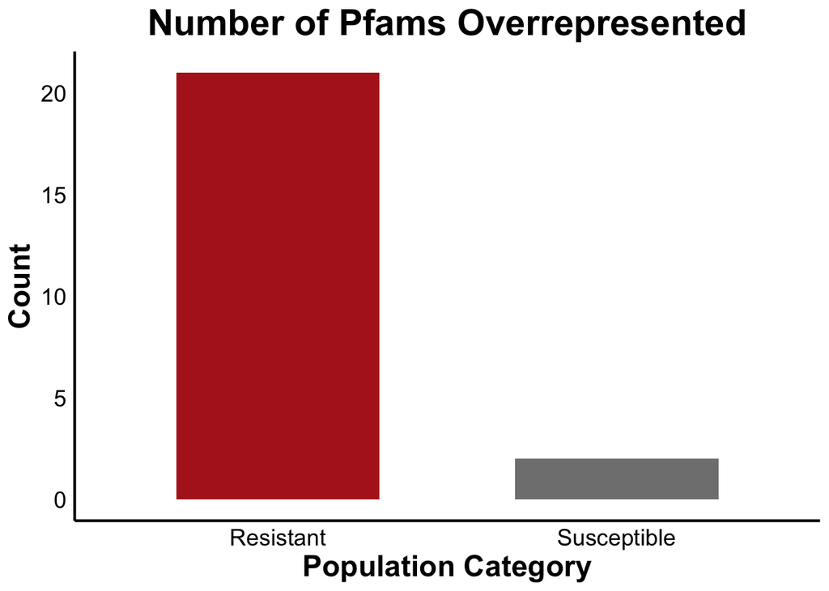

```r
# identify the category with higher mean proportion for each Pfam
pfam_assignment <- mean_proportions_significant %>%
  group_by(accession) %>%
  filter(mean_proportion == max(mean_proportion)) %>%
  ungroup()

# count total Pfams in each category
pfam_count <- pfam_assignment %>%
  group_by(group) %>%
  summarise(total_pfams = n())

# define colors
custom_colors <- c("Resistant" = "#B22222", "Susceptible" = "#808080")

# plot
figure_2A <- ggplot(pfam_count, aes(x = group, y = total_pfams, fill = group)) +
  geom_bar(stat = "identity", width = 0.6) +  # Bar plot with fixed width
  scale_fill_manual(values = custom_colors) +  # Apply custom colors
  labs(
    title = "Number of Pfams Overrepresented",
    x = "Population Category",
    y = "Count"
  ) +
  theme_minimal() +
  theme(
    plot.title = element_text(hjust = 0.5, vjust = 1, face = "bold", size = 22),
    axis.line = element_line(size = 0.8),
    axis.title = element_text(size = 18, face = "bold"),
    axis.text.y = element_text(size = 14, color = "black"),
    axis.text.x = element_text(size = 14, color = "black"),
    legend.position = "none",  # Remove legend since categories are labeled on the X-axis
    panel.grid.major = element_blank(),
    panel.grid.minor = element_blank()
  )
figure_2A
```

```r
# save with a large size so that nothing is cut off
ggsave(filename = "../R output/Figures/Figure_2A_total_enrichedpfams.jpg", plot = figure_2A, width = 7, height = 7, dpi = 300, units = "in")
```

Figure 2B: Plot highlighting select examples that show existence of multiple mechanisms of predation resistance

```r
defense_pfams <- mean_proportions_significant[mean_proportions_significant$accession %in% c(
  "PF00005.31",  # ABC transporter
  "PF00528.26",  # Binding-protein-dependent transport system inner membrane component
  "PF13450.10",  # NAD(P)-binding Rossmann-like domain
  "PF07992.18",  # Pyridine nucleotide-disulphide oxidoreductase
  "PF01593.28",  # Flavin-containing oxidoreductase
  "PF00494.23",  # Squalene/phytoene synthase
  "PF13304.10"   # AAA domain, putative AbiEii toxin, Type IV TA system
), ]


# define functional categories for grouping
defense_pfams$category <- case_when(
  defense_pfams$accession %in% c("PF00005.31", "PF00528.26") ~ "Transporters",
  defense_pfams$accession %in% c("PF13450.10", "PF07992.18", "PF01593.28", "PF00494.23") ~ "Oxidative Stress Response",
  defense_pfams$accession == "PF13304.10" ~ "Toxin-Antitoxin System"
)

# order categories as Transporters → Toxin-Antitoxin → Oxidative Stress
defense_pfams$category <- factor(defense_pfams$category, levels = c("Transporters", "Toxin-Antitoxin System", "Oxidative Stress Response"))

# define colors
custom_colors <- c("Resistant" = "#B22222", "Susceptible" = "#808080")

# define labels
label_mapping <- c(
  "PF13304.10" = "Putative AbiEii Toxin (Type IV System)",
  "PF00005.31" = "ABC Transporter",
  "PF00528.26" = "Binding Protein Transporter",
  "PF13450.10" = "NAD(P) Rossmann Domain",
  "PF07992.18" = "Pyridine Oxidoreductase",
  "PF01593.28" = "Flavin Containing Amine Oxidoreductase",
  "PF00494.23" = "Squalene/phytoene synthase"
)

# map shortened labels to df
defense_pfams$short_function <- label_mapping[defense_pfams$accession]

# move facet labels to the top & reorder Pfams within each category
defense_pfams$short_function <- with(defense_pfams, reorder(short_function, mean_proportion))
defense_pfams$group <- factor(defense_pfams$group, levels = c("Resistant", "Susceptible"))  # Change order

write.csv(defense_pfams, "../R output/defense_pfams.csv")
```

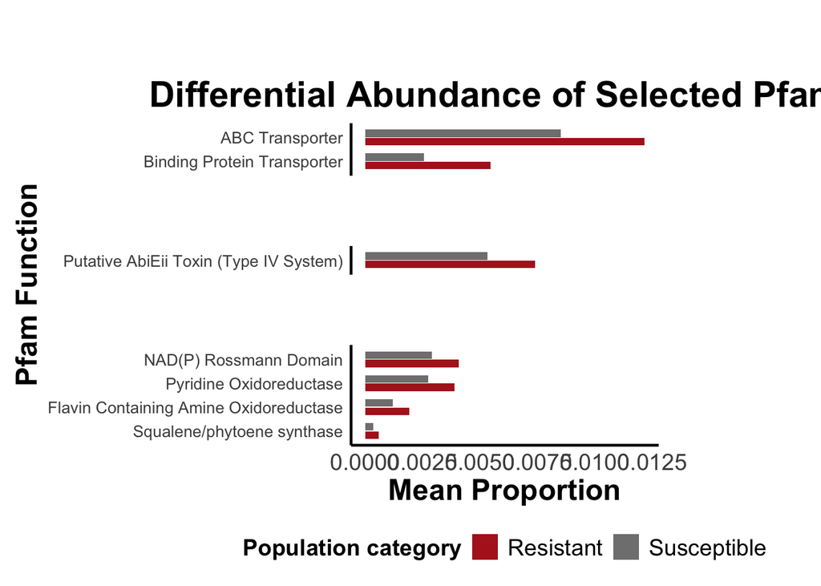

```r
# create the plot
figure_2B_prelabel <- ggplot(defense_pfams, aes(x = mean_proportion, y = short_function, fill = group)) +
  geom_bar(stat = "identity", position = position_dodge2(width = 0.2, preserve = "single"), width = 0.7) +
  facet_grid(rows = vars(category), scales = "free_y", space = "free_y") +
  scale_fill_manual(values = custom_colors, name = "Population category") +  # Ensure correct legend title
  labs(
    title = "Differential Abundance of Selected Pfams",
    x = "Mean Proportion",
    y = "Pfam Function"
  ) +
  theme_minimal() +
  theme(
    plot.title = element_text(hjust = 0.5, vjust = 1, face = "bold", size = 22),
    plot.margin = ggplot2::margin(50, 100, 10, 10),  # Increased space between title and first facet
    axis.title = element_text(size = 18, face = "bold"),
    axis.text.y = element_text(size = 10),  # Ensure readable Y-axis labels
    axis.text.x = element_text(size = 14),
    axis.line = element_line(size = 0.8),
    legend.position = "bottom",
    legend.text = element_text(size = 14),
    legend.title = element_text(size = 14, face = "bold"),
    strip.text = element_blank(),
    panel.spacing = unit(3, "lines"),  # Ensure spacing between facets
    panel.grid.major = element_blank(),
    panel.grid.minor = element_blank()
  )

# save the plot
ggsave(filename = "../R output/Figures/Figure_2B_prelabel_PfamDiffAbund.jpg",
       plot = figure_2B_prelabel, width = 10, height = 10, dpi = 600, units = "in")

figure_2B_prelabel
```

Plot Figure 2C: PCoA of 23 enriched pfams for all populations to see if any clustering

```r
sig_accessions <- unique(mean_proportions_significant$accession)
sigpfams_only_df <- subset(pfam_proportions_with_group, accession %in% sig_accessions)

# prepare data for PCoA
# matrix format
sigpfams_pcoa <- sigpfams_only_df %>%
  dplyr::select(bin, accession, proportion) %>%
  pivot_wider(names_from = accession, values_from = proportion)

# set NAs to 0
sigpfams_pcoa <- sigpfams_pcoa %>%
  mutate(across(everything(), ~replace(., is.na(.), 0)))

# remove text cols
data_sigfams_pcoa <- sigpfams_pcoa[, -1]

# compute Bray-Curtis dissimilarity matrix
sigfams_bray_curtis <- vegdist(data_sigfams_pcoa, method = "bray")

# perform PCoA
sigfams_pcoa_result <- cmdscale(sigfams_bray_curtis, eig = TRUE, k = 6)

# calculate variation explained by the first two axes
eigenvalues <- sigfams_pcoa_result$eig
total_variation <- sum(eigenvalues)
variation_explained <- eigenvalues / total_variation * 100
```

Plot 2C

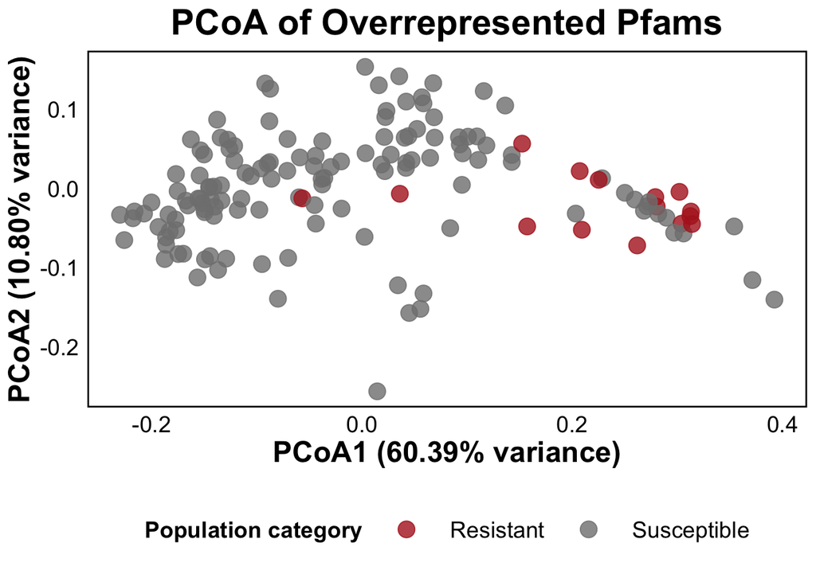

```r
# combine PCoA coordinates with bin and category info
sigfams_pcoa_plot_data <- data.frame(x = sigfams_pcoa_result$points[, 1],
                                     y = sigfams_pcoa_result$points[, 2],
                                     bin = sigpfams_pcoa[, 1]) %>%
  left_join(sig_bins, by = "bin")

# rename group labels
sigfams_pcoa_plot_data$group[sigfams_pcoa_plot_data$group == "resistant"] <- "Resistant"
sigfams_pcoa_plot_data$group[sigfams_pcoa_plot_data$group == "susceptible"] <- "Susceptible"

# Calculate percentages of variation explained by the first two axes for the labels
varPCoA1 <- variation_explained[1]
varPCoA2 <- variation_explained[2]

figure_2C <- ggplot(sigfams_pcoa_plot_data, aes(x = x, y = y, color = group)) +
  geom_point(size = 4.5, alpha = 0.8) +
  scale_color_manual(values = c("Resistant" = "#B22222", "Susceptible" = "#808080"), name = "Population category")+
  #scale_color_manual(values = c("Resistant" = "red", "Susceptible" = "blue")) +
  labs(x = paste("PCoA1 (", sprintf("%.2f", varPCoA1), "% variance)", sep=""),
       y = paste("PCoA2 (", sprintf("%.2f", varPCoA2), "% variance)", sep=""),
       color = "Group") +
  ggtitle("PCoA of Overrepresented Pfams") +
  theme_minimal() +
  theme(plot.title = element_text(hjust = 0.5, vjust = 1, face = "bold", size = 22),
        axis.line = element_blank(),
        axis.title = element_text(size = 18, face = "bold"),
        axis.text.y = element_text(size = 14, color = "black"),
        axis.text.x = element_text(size = 14, color = "black"),
        legend.position = "bottom",
        legend.text = element_text(size = 14),
        legend.title = element_text(size = 14, face = "bold"),
        legend.key.size = unit(3,"line"),
        panel.grid.major = element_blank(),
        panel.grid.minor = element_blank(),
        panel.border = element_rect(colour = "black", fill=NA, size=1)
        )

ggsave(filename = "../R output/Figures/Figure_2C_pCoA_enrichedPfams.jpg",
       plot = figure_2C, width = 9, height = 7, dpi = 300, units = "in")

figure_2C
```

Plot S2A: Differential abundance of 23 overrepresented Pfams

```r
custom_colors <- c("Resistant" = "#B22222", "Susceptible" = "#808080")

# Create the bar plot
figure_S2A <- ggplot(mean_proportions_significant, aes(x = mean_proportion, y = function., fill = group)) +
  geom_bar(stat = "identity", position = position_dodge2(width = 0.2, preserve = "single"), width = 0.7) +
  scale_fill_manual(values = custom_colors, name = "Population category") +
  labs(
    title = "Differential Abundance of 23 Overrepresented Pfams",
    x = "Mean Proportion",
    y = "Pfam Function"
  ) +
  theme_minimal() +
  theme(
    plot.title = element_text(hjust = 0.5, vjust = 1, face = "bold", size = 22),
    plot.margin = ggplot2::margin(50, 100, 10, 10),
    axis.title = element_text(size = 18, face = "bold"),
    axis.text.y = element_text(size = 10),
    axis.text.x = element_text(size = 14),
    axis.line = element_line(size = 0.8),
    legend.position = "bottom",
    legend.text = element_text(size = 14),
    legend.title = element_text(size = 14, face = "bold"),
    strip.text = element_blank(),
    panel.spacing = unit(3, "lines"),
    panel.grid.major = element_blank(),
    panel.grid.minor = element_blank()
  )

# Save the plot
ggsave(filename = "../R output/Figures/Figure_S2A_Enriched_Pfams.jpg",
       plot = figure_S2A,
       width = 15, height = 10, dpi = 300, units = "in")
```

Plot S2B: Plot of top 10 Eigen values from the overrepresented Pfam PCoA

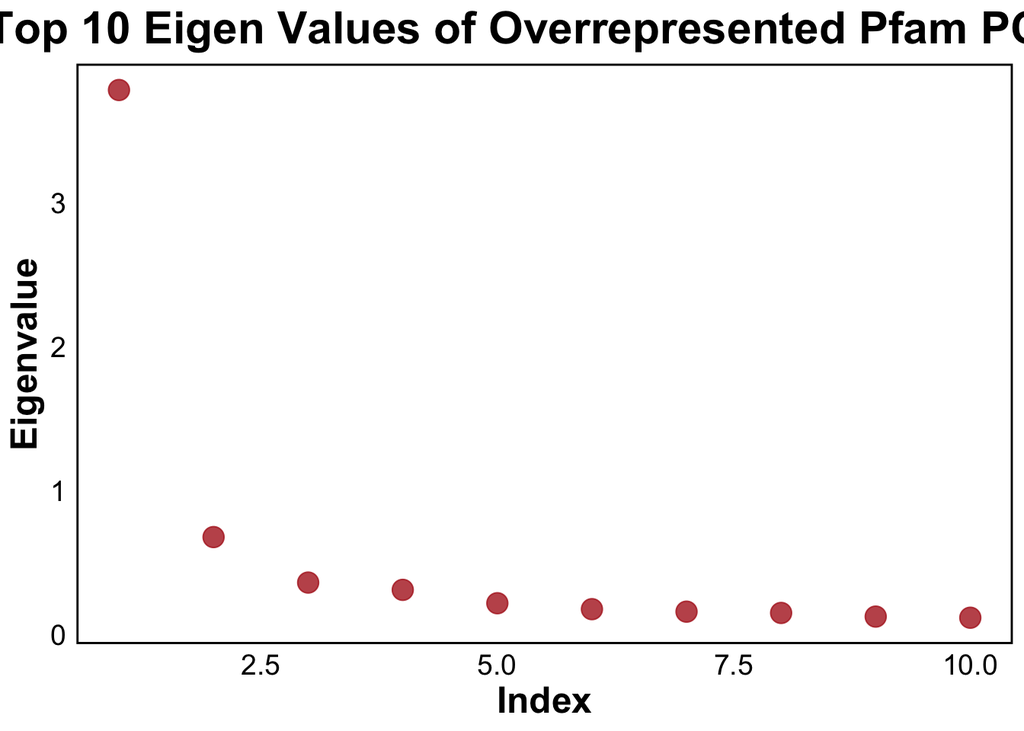

```r
pcoa_eigenvalues_df <- data.frame(
  Index = 1:10,
  Eigenvalue = eigenvalues[1:10]
)

figure_S2B <- ggplot(pcoa_eigenvalues_df, aes(x = Index, y = Eigenvalue)) +
  geom_point(size = 4.5, color = '#B22222', alpha = 0.8) + # Add points
  theme_minimal() +
  ggtitle("Top 10 Eigen Values of Overrepresented Pfam PCoA") +
  theme_minimal() +
  theme(plot.title = element_text(hjust = 0.5, vjust = 1, face = "bold", size = 22),
        axis.line = element_blank(),
        axis.title = element_text(size = 18, face = "bold"),
        axis.text.y = element_text(size = 14, color = "black"),
        axis.text.x = element_text(size = 14, color = "black"),
        panel.grid.major = element_blank(),
        panel.grid.minor = element_blank(),
        panel.border = element_rect(colour = "black", fill=NA, size=1))

ggsave(filename = "../R output/Figures/Figure_S2B_eigenvalues.jpg",
       plot = figure_S2B, width = 9, height = 7, dpi = 300, units = "in")
figure_S2B
```

Plot S2C: Plot PCoA of 23 enriched pfams only for only resistant populations to see if there is clustering based on taxonomy

```r
# prepare data
phylum_info <- bins_extendedinfo %>%
  select(bin, t_phylum) %>%
  distinct()  # Retain unique MAG-phylum pairs

pcoa_ready <- filtered_proportions_for_tests %>%
  filter(group == "Resistant") %>%
  semi_join(significant_pfams_with_desc, by = "accession") %>%
  select(bin, accession, proportion)

pcoa_matrix <- pcoa_ready %>%
  pivot_wider(names_from = accession, values_from = proportion, values_fill = 0) # create MAG x Pfam Matrix
mag_names <- pcoa_matrix$bin # retain MAG names
pcoa_matrix <- pcoa_matrix %>% select(-bin) # remove from matrix
bray_curtis_dist <- vegdist(pcoa_matrix, method = "bray") # Bray-Curtis Dissimilarity

pcoa_res <- cmdscale(bray_curtis_dist, k = 2, eig = TRUE) # perform PCoA

pcoa_df <- as.data.frame(pcoa_res$points) # convert to dataframe
colnames(pcoa_df) <- c("PCoA1", "PCoA2")
pcoa_df$MAG <- mag_names  # Re-add MAG names

# merge with phylum information
pcoa_df <- pcoa_df %>%
  left_join(phylum_info, by = c("MAG" = "bin")) %>%
  mutate(t_phylum = ifelse(is.na(t_phylum), "Unknown", t_phylum))

# define colors for phyla present
custom_colors <- c(
  "Proteobacteria" = "#E1A91F",
  "Planctomycetota" = "#B39BC8",
  "Actinobacteriota" = "#D72638",
  "Cyanobacteria" = "#78C2BE",
  "Chloroflexota" = "#BCCF02")

pcoa_df$t_phylum <- factor(pcoa_df$t_phylum, levels = names(custom_colors)) # set phylum as a factor for consistent color mapping
```

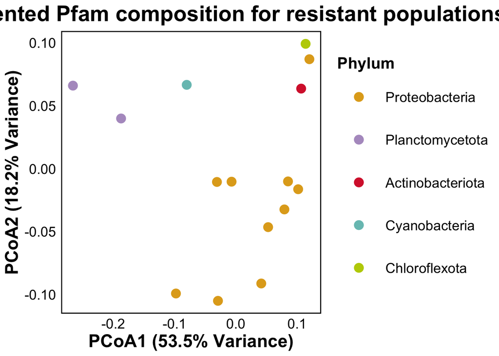

```r
# plot
figure_S2C <- ggplot(pcoa_df, aes(x = PCoA1, y = PCoA2, label = MAG, color = t_phylum)) +
  geom_point(size = 4, alpha = 1) +
  scale_color_manual(values = custom_colors) +  # Apply custom colors
  labs(
    title = "Overrepresented Pfam composition for resistant populations",
    x = paste0("PCoA1 (", round(pcoa_res$eig[1] / sum(pcoa_res$eig) * 100, 1), "% Variance)"),
    y = paste0("PCoA2 (", round(pcoa_res$eig[2] / sum(pcoa_res$eig) * 100, 1), "% Variance)"),
    color = "Phylum"
  ) +
  theme_minimal() +
  theme(
    plot.title = element_text(hjust = 0.5, vjust = 1, face = "bold", size = 22),  # Bold and centered title
    axis.line = element_blank(),
    axis.title = element_text(size = 18, face = "bold"),
    axis.text.y = element_text(size = 14, color = "black"),
    axis.text.x = element_text(size = 14, color = "black"),
    legend.position = "right",
    legend.text = element_text(size = 14),
    legend.title = element_text(size = 16, face = "bold"),
    legend.key.size = unit(3,"line"),
    panel.grid.major = element_blank(),
    panel.grid.minor = element_blank(),
    panel.border = element_rect(colour = "black", fill=NA, size=1)
  )

figure_S2C
```

```r
# save
ggsave(filename = "../R output/Figures/Figure_S2A_PCoA_enrichedpfams_taxonomy.jpg", plot = figure_S2C,width = 12, height = 7, dpi = 300, units = "in")
```

Permanova on Pfams of resistant mags based on taxonomy

```r
# ensure the taxonomy table includes only resistant MAGs
phylum_info_filtered <- phylum_info %>% filter(bin %in% mag_names)

# run PERMANOVA with only resistant MAGs
permanova_resistant <- adonis2(bray_curtis_dist ~ t_phylum, data = phylum_info_filtered, permutations = 999)
print(permanova_resistant)  # If p < 0.05, taxonomic structure is significant
```

```
## Permutation test for adonis under reduced model
## Permutation: free
## Number of permutations: 999
##
## adonis2(formula = bray_curtis_dist ~ t_phylum, data = phylum_info_filtered, permutations = 999)
##          Df SumOfSqs      R2      F Pr(>F)
## Model     4  0.20482 0.57438 3.3738  0.002 **
## Residual 10  0.15177 0.42562
## Total    14  0.35659 1.00000
## ---
## Signif. codes:  0 '***' 0.001 '**' 0.01 '*' 0.05 '.' 0.1 ' ' 1
```

Permanova indicates significant difference in profiles based on taxonomy. But, since there is uneven number of taxa within phyla, check if taxonomic groups differ in dispersion to validate PERMANOVA

```r
dispersion_test <- betadisper(bray_curtis_dist, phylum_info_filtered$t_phylum)
anova(dispersion_test)
```

```
## Analysis of Variance Table
##
## Response: Distances
##           Df   Sum Sq   Mean Sq F value  Pr(>F)
## Groups     4 0.029773 0.0074432   5.646 0.01216 *
## Residuals 10 0.013183 0.0013183
## ---
## Signif. codes:  0 '***' 0.001 '**' 0.01 '*' 0.05 '.' 0.1 ' ' 1
```

Here, p < 0.05 suggests that dispersion differences may affect clustering.